# PEMBAHASAN PENELITIAN

## PENERAPAN ALGORITMA DECISION TREE C5.0 PADA ANALISIS HUBUNGAN KEHADIRAN DAN DATA DIRI MAHASISWA TERHADAP NILAI AKHIR MATAKULIAH REKAYASA PERANGKAT LUNAK

Tahapan penelitian yang akan dilakukan mengikuti proses standar pada data mining yaitu *Cross-Industry Standard Process for Data Mining* (CRISP-DM), sebagai berikut :

1. Pemahaman bisnis (*Business understanding*) : menentukan masalah data mining yang akan diselesaikan
2. Pemahaman data (*Data understanding*) : mengumpulkan data dan memilih data-data yang dibutuhkan
3. Persiapan data (*Data preparation*) : mengubah format data kebentuk yang dapat diolah dengan algoritma C.50
4. Pemodelan (*Modelling*) : pembuatan model pohon keputusan menggunakan algoritma C.50
5. Evaluasi (*Evaluation*) : evaluasi model yang dihasilkan
6. Penyebaran (*Deployment*) : pembuatan laporan penelitian

# 1. Pemahaman bisnis (*Business understanding*)

:: menentukan masalah data mining yang akan diselesaikan

Telah dijabarkan dalam proposal penelitian

# 2. Pemahaman data (*Data understanding*) :

:: mengumpulkan data dan memilih data-data yang dibutuhkan

Penelitian ini menggunakan data mahasiswa RPL kelas S7C, S7D, S7E dan S7F

Attribut yang diteliti antara lain :

1. kehadiran : persentasi kehadiran
2. jenis kelamin : laki-laki atau perempuan
3. usia : usia mahasiswa
4. kerja : status kerja (sudah bekerja atau belum)
5. menikah : status pernikahan (sudah menikah atau belum)
6. pendidikan : jenjang pendidikan sebelum S1 (SMA, SMK, dll) 7 ipk : nilai IPK terkahir
7. nilai : nilai akhir matakuliah RPL

Data primer diperoleh dari 3 sumber:

1. TU fakultas, data yang didapat dari TU Fakultas adalah data nilai akhir
2. Kuisioner langsung ke mahasiswa, kuisioner ini untuk melengkapi data jenis kelamin, usia, kerja, menikah, pendidikan dan ipk
3. Rekap absensi mahasiswa dari dosen yang mengampu untuk melengkapi data persen kehadiran

Kuisiner dilakukan secara langsung oleh tim peneliti kepada mahasiswa saat mahasiswa sedang mengambil matakuliah di semester 8, dengan meminta izin dosen yang sedang mengampu.

Dari total 154 responden, kuisiner yang berhasil dikumpulkan ada 81 mahasiswa (53%).

Data disimpan dalam file xls **data_penelitian.xls**

# 3. Persiapan data (*Data preparation*) :

:: mengubah format data kebentuk yang dapat diolah dengan algoritma C.50

Dari data responden yang balik, terdapat 3 data mahasiswa yang kurang lengkap, yaitu data IPK terakhir. Ke 3 data tersebut peneliti gantikan dengan IPK rata-rata data responden yang mengikuti kuisioner.

data diload ke R dan sejumlah penyesuaian fomat/tipe data dilakukan

sejumlah paket tambahan diload ke dalam sistem :

1. xlsx (load data xls ke R)
2. tidyverse (explorasid dan manipulasi data di R)

```r
# set working directory
setwd("D:/SHARE/BIG DATA/Data Science/penelitian 2017/coding")

# load package xlsx untuk import data xls ke R
require(xlsx)
# load data
#data_penelitian <- read.xlsx("data_penelitian.xlsx", sheetIndex = 5, stringsAsFactors=FALSE)

# nilai dipermudah menjadi A,B,C,D saja, menghilangkan +-
data_penelitian <- read.xlsx("data_penelitian.xlsx", sheetIndex = 6, stringsAsFactors=FALSE)

#str(data_penelitian)

# ubah tipe data kelas, jenkel, kerja, pendidikan as factor
data_penelitian$kelas <- as.factor(data_penelitian$kelas)
data_penelitian$jenkel <- as.factor(data_penelitian$jenkel)
data_penelitian$kerja <- as.factor(data_penelitian$kerja)
data_penelitian$menikah <- as.factor(data_penelitian$menikah)
data_penelitian$pendidikan <- as.factor(data_penelitian$pendidikan)
data_penelitian$nilai <- as.factor(data_penelitian$nilai)
data_penelitian$ipk <- as.numeric(data_penelitian$ipk)
# tampilkan
#head(data_penelitian)
#summary(data_penelitian$nilai)

# filter hanya data kuisioner yang balik
library(tidyverse)
data_penelitian_lengkap <- data_penelitian %>%
  filter(!is.na(jenkel))

#head(data_penelitian_lengkap)
#str(data_penelitian_lengkap)
```

data exploration dilakukan untuk memahami karakter data

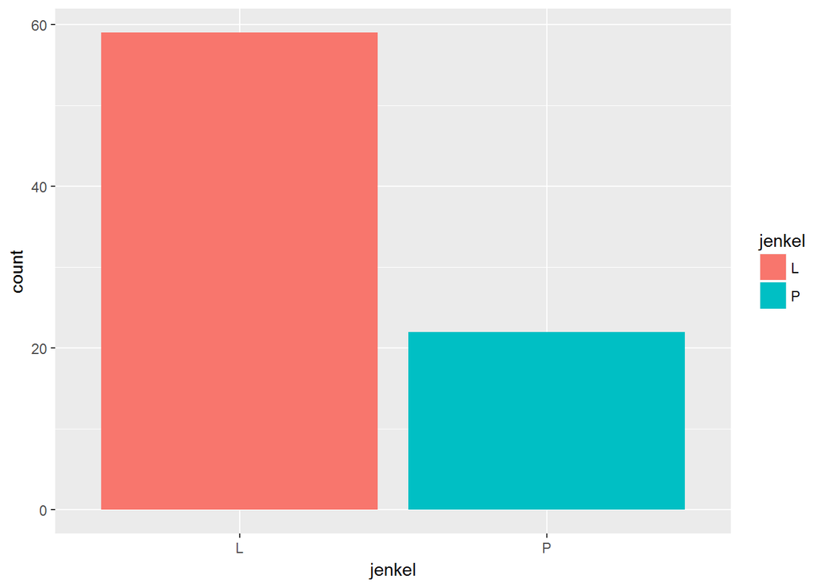

```r
# menggunakan paket ggplot2 dalam library tidyverse
# sebaran data jenis kelamin
ggplot(data=data_penelitian_lengkap) +
  geom_bar(mapping = aes(x=jenkel, fill=jenkel ))
```

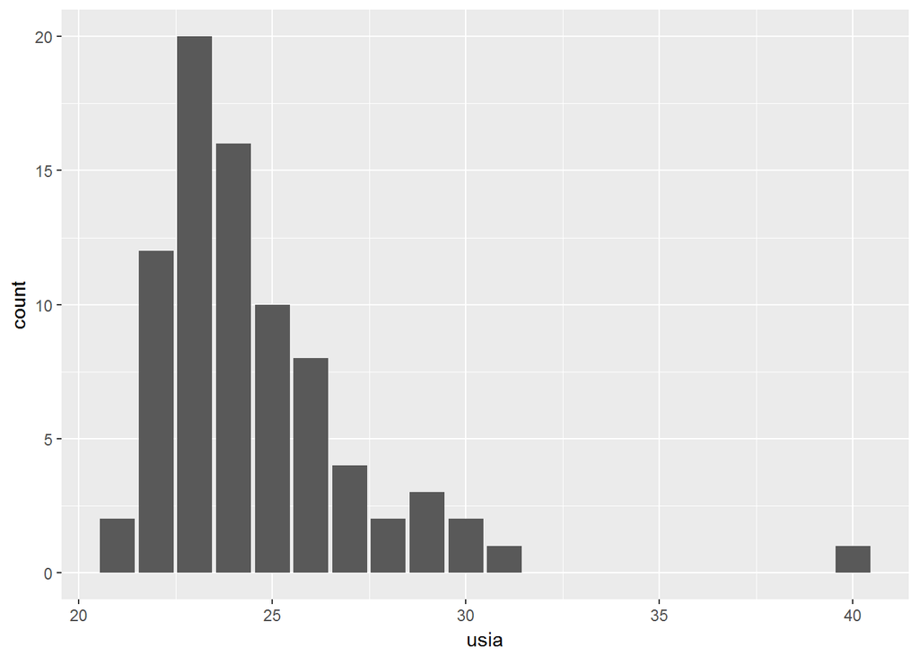

```r
ggplot(data=data_penelitian_lengkap) +
  geom_bar(mapping = aes(x=usia, fill=usia ))
```

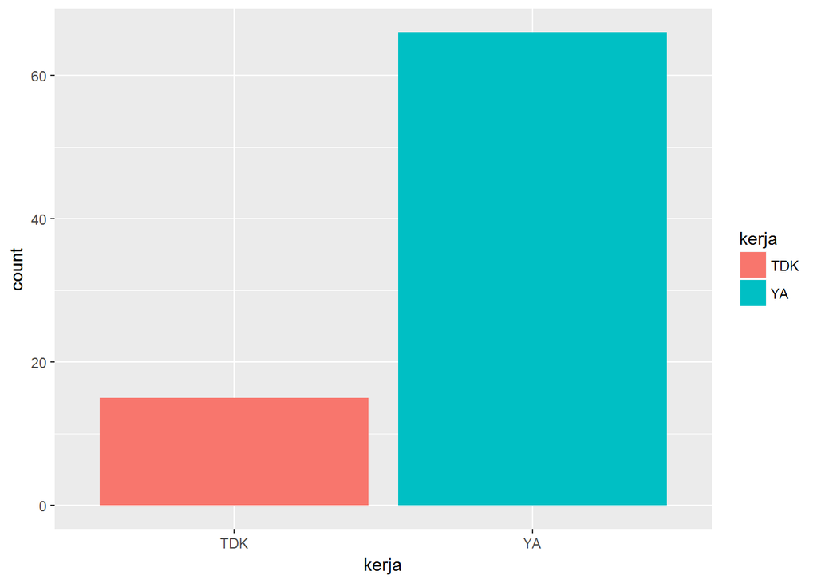

```r
ggplot(data=data_penelitian_lengkap) +
  geom_bar(mapping = aes(x=kerja, fill=kerja ))
```

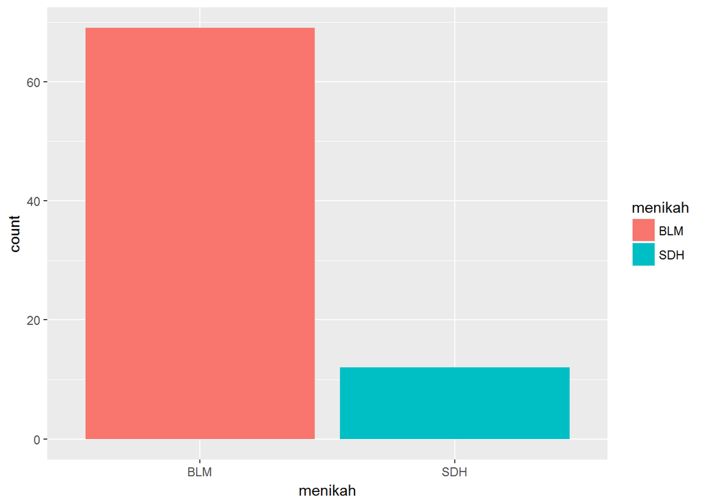

```r
ggplot(data=data_penelitian_lengkap) +
  geom_bar(mapping = aes(x=menikah, fill=menikah ))
```

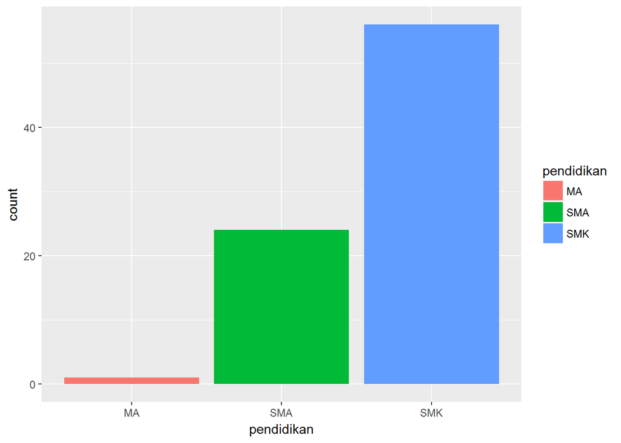

```r
ggplot(data=data_penelitian_lengkap) +
  geom_bar(mapping = aes(x=pendidikan, fill=pendidikan ))
```

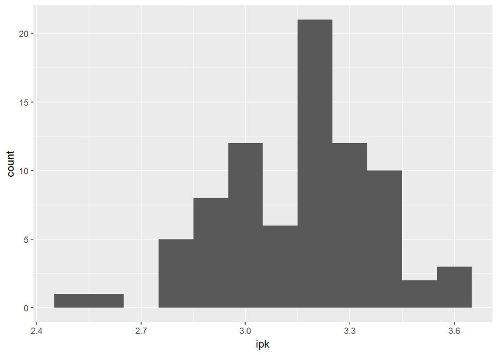

```r
ggplot(data=data_penelitian_lengkap, aes(x=ipk)) +
  geom_histogram(binwidth = 0.1)
```

# 4. Pemodelan (*Modelling*) :

:: pembuatan model pohon keputusan menggunakan algoritma C.50

1. acak data
2. bagi data dalam 2 bagian
1. training (80% data)
2. testing (20% data)
3. buat model

```r
require(C50)
```

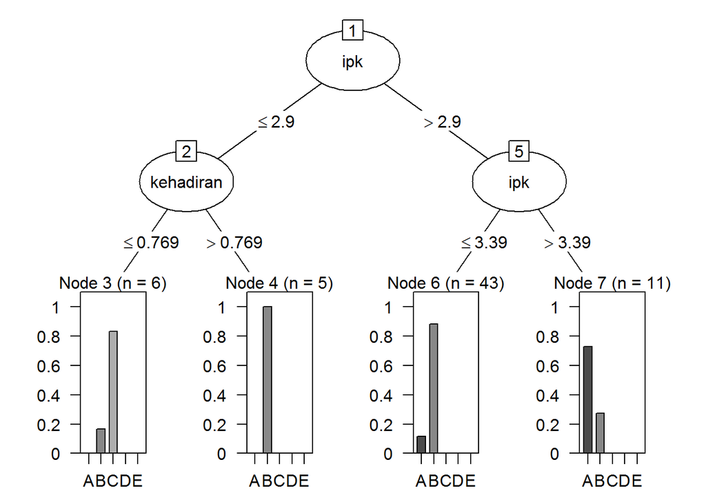

```r
# acak data
set.seed(1000)
bilangan_acak <- runif(nrow(data_penelitian_lengkap))
data_penelitian_acak <- data_penelitian_lengkap[order(bilangan_acak),]
#head(data_penelitian_acak)


lihat_sebaran_data <- data_penelitian_acak %>%
  group_by(kelas) %>%
  summarise(
    count = n()
  )


# bagi data  menjadi data training dan testing <- 80% dan 20%
#0.8*81 = 65 data training
#81-65 = 16 data testing

data_training <- data_penelitian_acak[1:65,]
data_testing <- data_penelitian_acak[66:81,]


#library(stringr)
#data_training <- select(data_penelitian_acak, kelas, kehadiran, usia, #jenkel, ipk,  nilai)
#%>%
#  filter(str_detect(kelas,"S7D"))

# model dengan atribut lengkap
dt1 <- select(data_training, kehadiran, jenkel, usia, kerja, menikah, pendidikan, ipk)

dt2 <- select(data_training, nilai)

m1 <- C5.0(dt1[,],dt2[,])
plot(m1)
```

```r
summary(m1)
```

```
##
## Call:
## C5.0.default(x = dt1[, ], y = dt2[, ])
##
##
## C5.0 [Release 2.07 GPL Edition]      Sun Jul 16 15:11:13 2017
## -------------------------------
##
## Class specified by attribute `outcome'
##
## Read 65 cases (8 attributes) from undefined.data
##
## Decision tree:
##
## ipk <= 2.9:
## :...kehadiran <= 0.7692308: C (6/1)
## :   kehadiran > 0.7692308: B (5)
## ipk > 2.9:
## :...ipk <= 3.39: B (43/5)
##     ipk > 3.39: A (11/3)
##
##
## Evaluation on training data (65 cases):
##
##      Decision Tree
##    ----------------
##    Size      Errors
##
##       4    9(13.8%)   <<
##
##
##     (a)   (b)   (c)   (d)   (e)    <-classified as
##    ----  ----  ----  ----  ----
##       8     5                      (a): class A
##       3    43     1                (b): class B
##                   5                (c): class C
##                                    (d): class D
##                                    (e): class E
##
##
##  Attribute usage:
##
##  100.00% ipk
##   16.92% kehadiran
##
##
## Time: 0.0 secs
```

# 5. Evaluasi (*Evaluation*) :

:: evaluasi model yang dihasilkan

```r
# buat prediksi
p1 <- predict(m1, data_testing[,c(-1,-2,-4,-11)])
p1
```

```
##  [1] B B B B B B B B B B B B A B B B
## Levels: A B C D E
```

```r
data_testing[,c(11)]
```

```
##  [1] B B A B B B B B B B B B B B B C
## Levels: A B C D E
```

```r
table(data_testing[,c(11)], p1)
```

```
##    p1
##      A  B  C  D  E
##   A  0  1  0  0  0
##   B  1 13  0  0  0
##   C  0  1  0  0  0
##   D  0  0  0  0  0
##   E  0  0  0  0  0
```

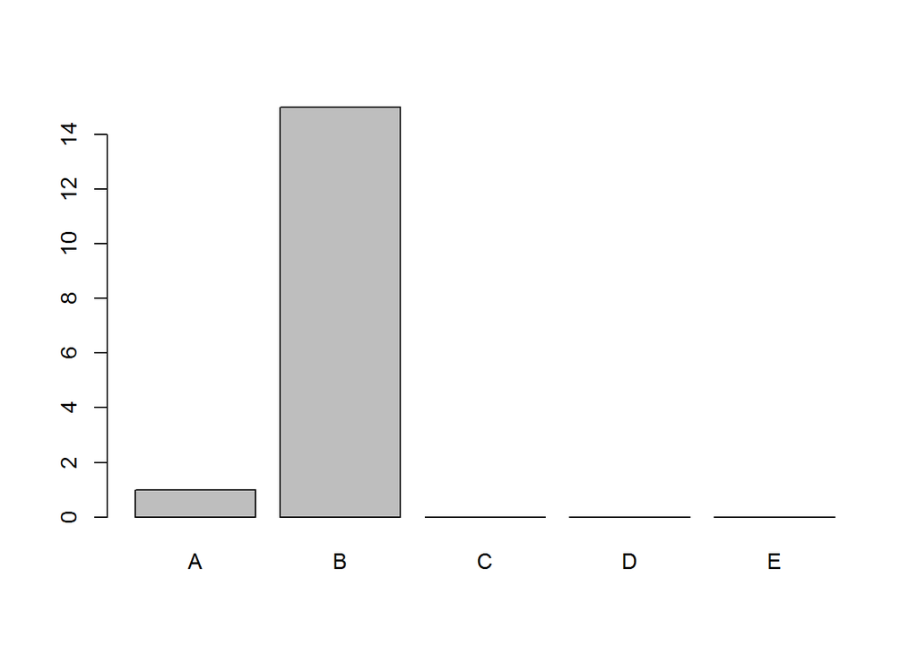

```r
plot(p1)
```

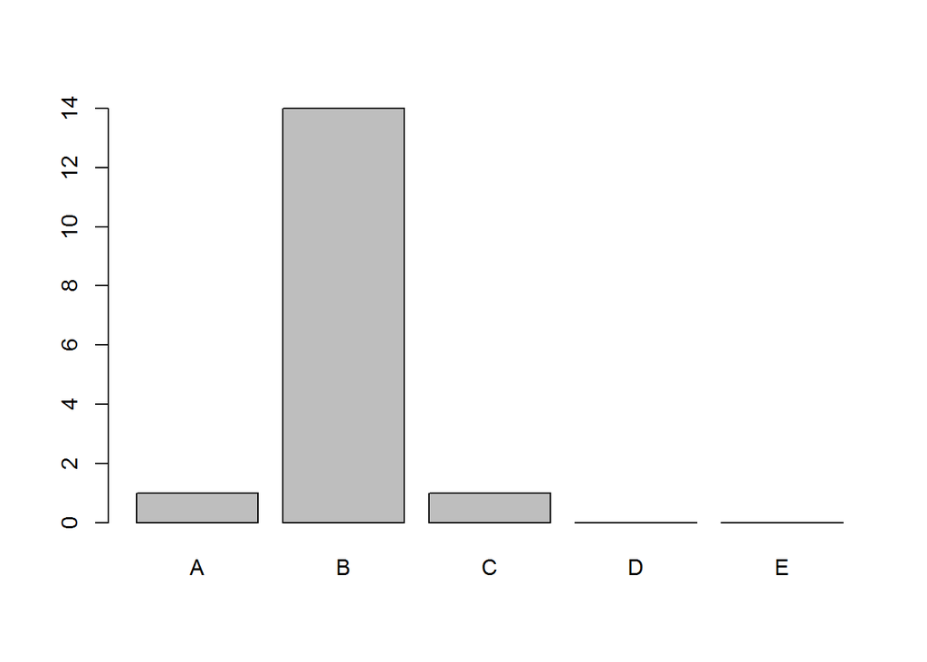

```r
plot(data_testing[,c(11)])
```

# 6. Penyebaran (*Deployment*) :

:: pembuatan laporan penelitian

pembuatan laporan menggunakan RMarkdown, sehingga laporan dapat dibuat langsung bersamaan dengan proses penelitian.

# kesimpulan

ada yang menarik dari penelitian ini, yaitu ternyata yang paling berpengaruh terhadap prediksi nilai mahasiswa adalah IPK terakhir